# COVID Analysis

Jonathan Cummings

7/17/2020

# Some Covid Analyses

What follows are the statistics and visualizations regarding COVID-19 that I find informative, important, or were just interesting to me to create as I learn more about data visualization. There are plenty of other analyses available, and analyses that come from disease experts, which I am not, so I encourage you to read and look at those as well!

The analyses use data last updated on 7/17/2020.

## Global Analyses

### Global Total Cases

Currently the nation with the fewest per capita confirmed cases is Papua New Guinea at 1 in every 813,891 individuals.  
The nation with the most per capita confirmed cases is Qatar at 1 in every 27.  
The global prevalence is 1 in every 563 individuals have had a confirmed case of COVID-19.

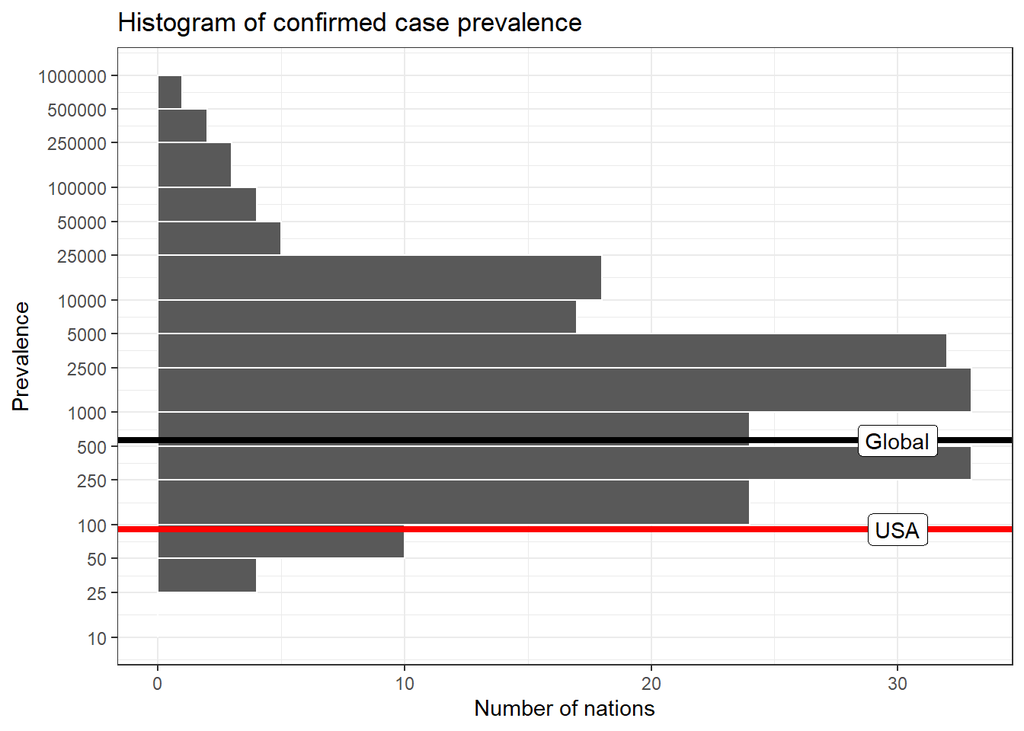

Distribution of national confirmed COVID-19 case prevalence.

### Global Deaths

Currently the nation with the fewest per capita deaths is Burundi at 1 in every 11,900,836 individuals.  
The nation with the most per capita deaths is San Marino at 1 in every 808 individuals.  
Globally 1 in every 13,176 individuals has died from COVID-19.  
1 in every 23 individuals who have contracted COVID-19 have died, a death rate of 4.28%.

If the current death rate in each nation remains the same, then based on the number of currently active cases, i.e. without additional infections, the current global death toll of 591,802 would be expected to increase to 673,945.

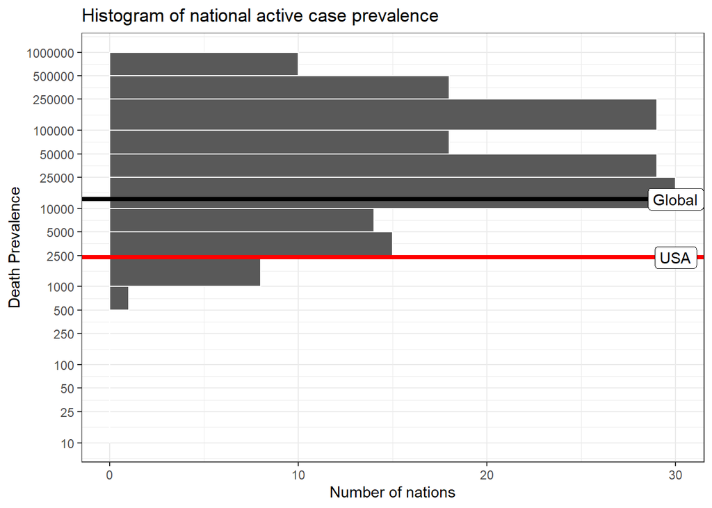

Distribution of national COVID-19 death prevalence.

### Global Active Cases

Currently their are 15 nations without any active cases of COVID-19. The most populous nation without any active cases is Laos.  
The nation with the most per capita active cases is French Guiana at 1 in every 118 individuals.  
The global prevalence is 1 in every 1,702 individuals with an active case of COVID-19.

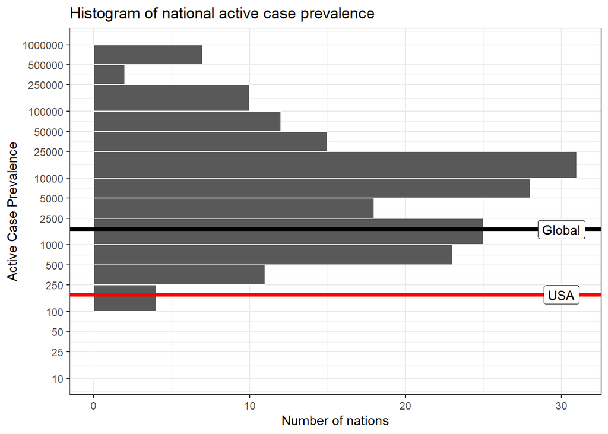

Distribution of national active COVID-19 case prevalence.

## United States of America Analyses

### National Status

In the USA 1 in every 91 people has had a confirmed case of COVID-19, 1 in every 179 has an active case, and 1 in every 2,357 individuals has died. The USA in ranked in position 12 for per capita cases, position 2 for per capita active cases, and position 9 for per capita deaths.

### USA Total Cases

Currently the state with the fewest per capita confirmed cases is Hawaii at 1 in every 1,095 individuals.  
The nation with the most per capita confirmed cases is New York at 1 in every 45.

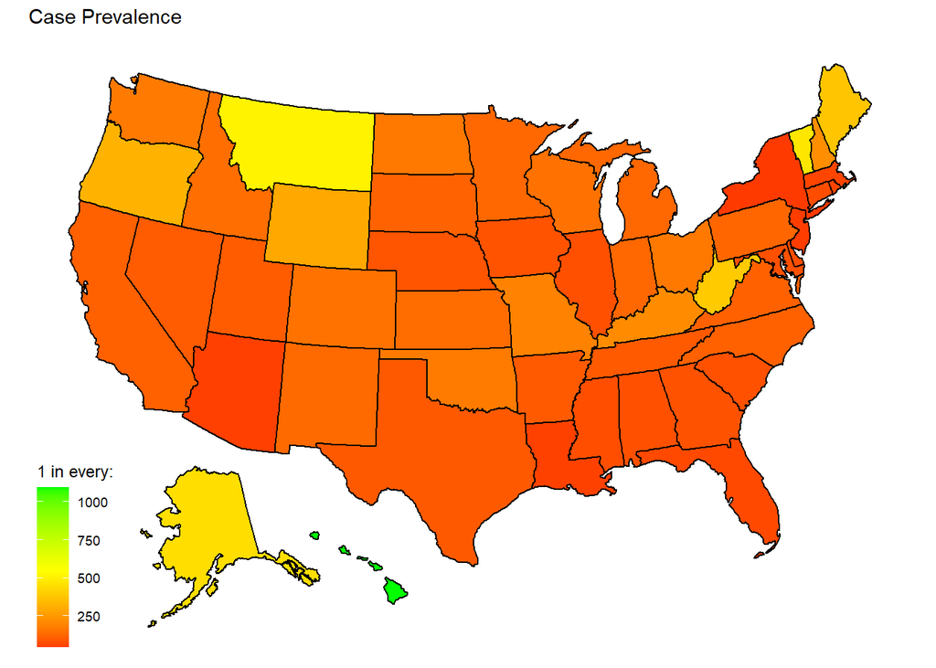

Map of Per Capita Confirmed Case Prevalence by State

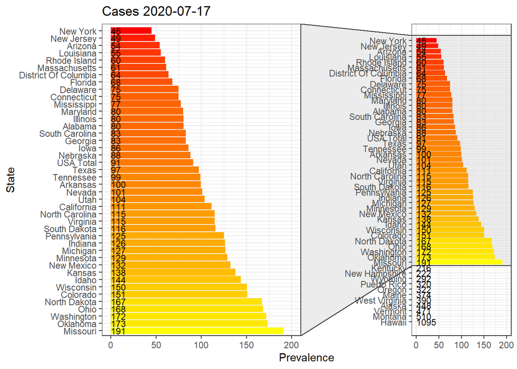

### USA Deaths

Currently the state with the fewest per capita deaths is Hawaii at 1 in every 62,500 individuals.  
The state with the most per capita deaths is New Jersey at 1 in every 566 individuals.

In the USA 1 in every 26 individuals who have contracted COVID-19 have died, a death rate of 3.87%. If the current death rate remains the same, then based on the number of currently active cases, i.e. without additional infections, the current national death toll of 140,442 would be expected to increase to 211,924.

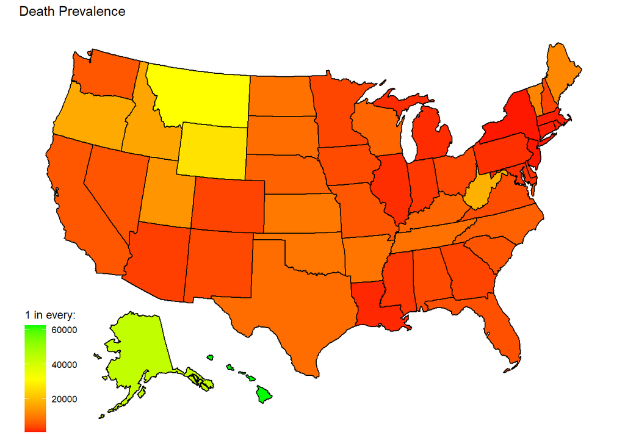

Map of Per Capita Deaths by State

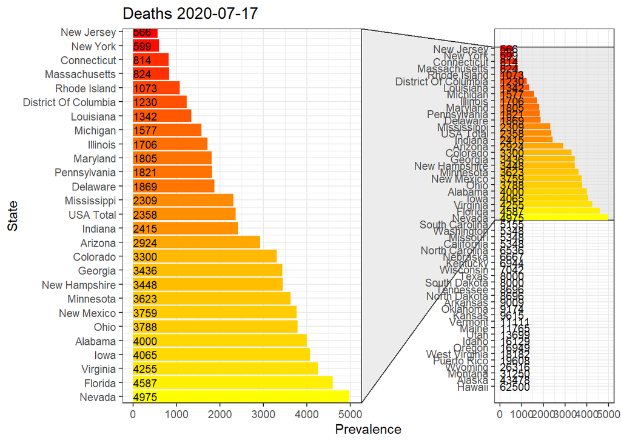

Prevalence of Deaths by State

### USA Active Cases

Currently the state with the fewest per capita active cases is Hawaii at 1 in every 4,436 individuals.  
The state with the most per capita active cases is Arizona at 1 in every 63 individuals.

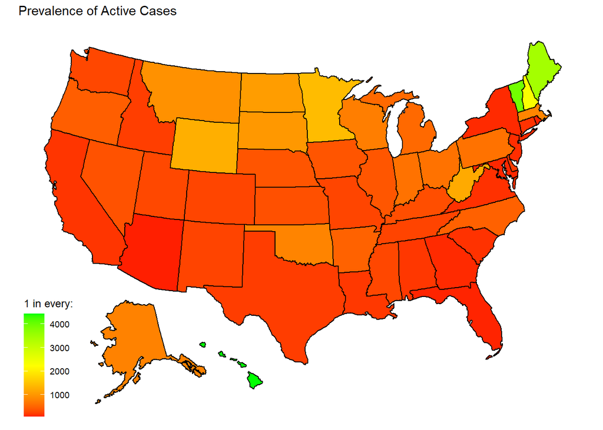

Map of Per Capita Active Case Prevalence by State

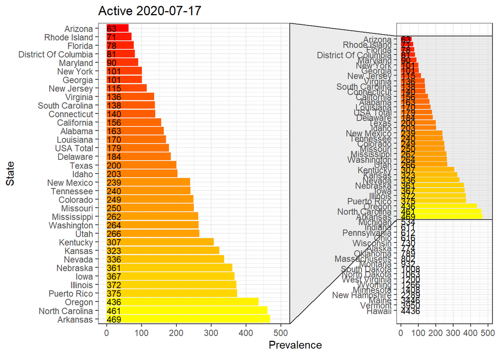

Prevalence of Active Cases by State

### Regional Analyses

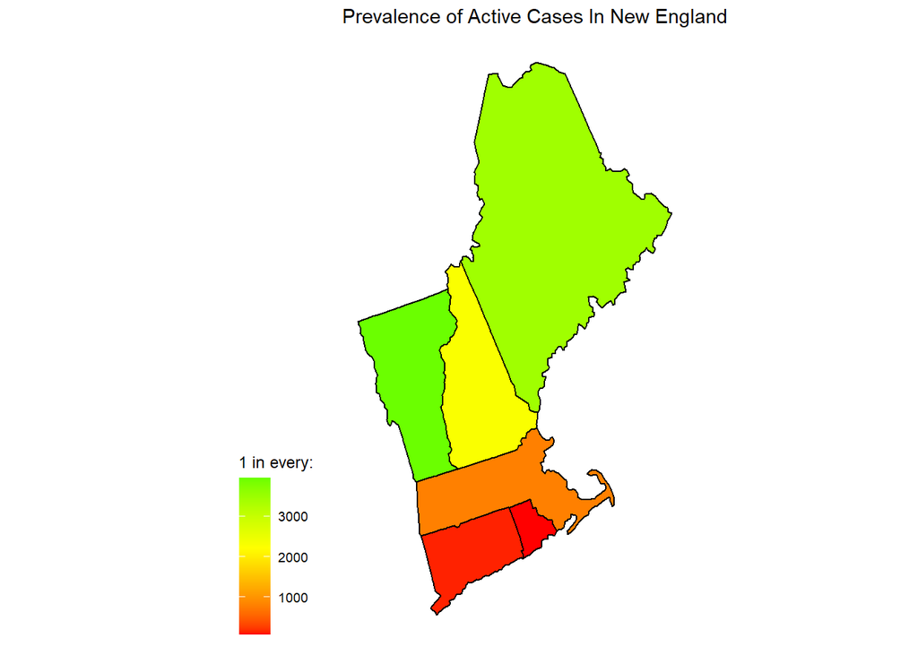

#### Status of Cases in the North versus the South

One question I’ve become curious about is the status of cases in the North versus the South. I defined states in the north as those with major populaton centers north of D.C. and Kansas City, and those with population centers south of those cities as southern states.

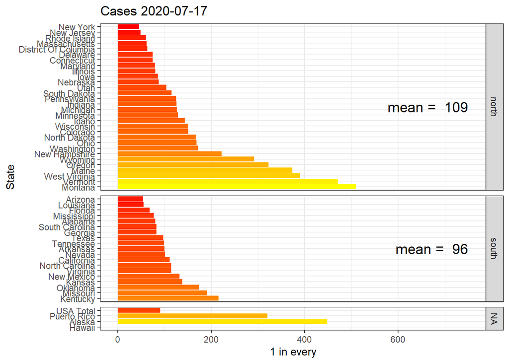

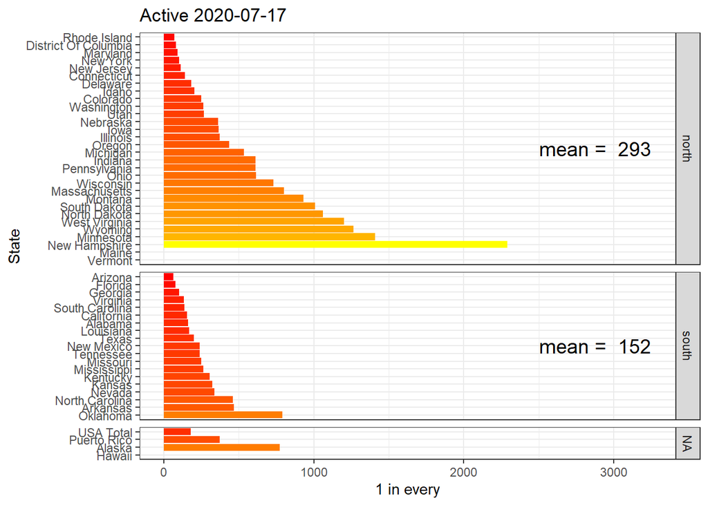

| NorthOrSouth | Active | Cases | Deaths | Active_Prevalence | Prevalence | Death_Prevalence | PercentActive |
| --- | --- | --- | --- | --- | --- | --- | --- |
| north | 618,303 | 1,663,656 | 101,155 | 293 | 109 | 2,224 | 37.17 |
| south | 1,193,223 | 1,885,840 | 36,673 | 152 | 96 | 4,308 | 63.27 |